# Using Census Data for Analysis and Making Maps in R

Richard Ressler

2020-04-20

# 1 Learning Outcomes

- Download and work with Census Bureau data
- Create maps in R using Census Bureau data.
- References:
  - [tidycensus](https://walkerke.github.io/tidycensus/articles/spatial-data.html)
  - [tigris package](https://cran.r-project.org/web/packages/tigris/index.html)
  - [Simple Features](https://cran.r-project.org/web/packages/sf/vignettes/sf1.html).
  - The US Census Bureau has numerous location and other data sets on its site or with links to other authoritative sites.
- [Census Bureau](https://www.census.gov/data.html)

# 2 tidycensus Package

- tidycensus allows users to interface with the US Census Bureau’s decennial Census and five-year American Community Survey APIs and return tidyverse-ready data frames, with the option for including *simple feature* geometry at various levels.
- Install the tidycensus package using the console
- Load the package

  ```r
  library(tidycensus)
  library(tidyverse)
  ```

## 2.1 Request a key from the census bureau:

https://api.census.gov/data/key_signup.html  
- You should get an email in a few seconds. C Lick on the link in the email to activate your key. - Copy the key from the email - it will be long….

### 2.1.1 Set up your key:

````
```r
#key_set("CENSUS_API_KEY_SECURE")
# when queried for a password use your new key
# # Do not run with INSTALL = TRUE as it will put our key in plain text in your  Renviron file
```
````

## 2.2 tidycensus Functions for the Decennial Census and the American Community Survey

- There are two major functions implemented in tidycensus:
  - `get_decennial()` grants access to the 1990, 2000, and 2010 decennial US Census APIs, and
  - `get_acs()` grants access to the 5-year American Community Survey APIs.
- See the help page
- Let’s look at median gross rent by state in 1990:

  ```r
  m90 <- get_decennial(geography = "state", variables = "H043A001", year = 1990, key = Sys.getenv("CENSUS_API_KEY"))
  head(m90)
  ```

  ```r
  nrow(m90)
  ```

  ```
  ## [1] 51
  ```

- Now plot

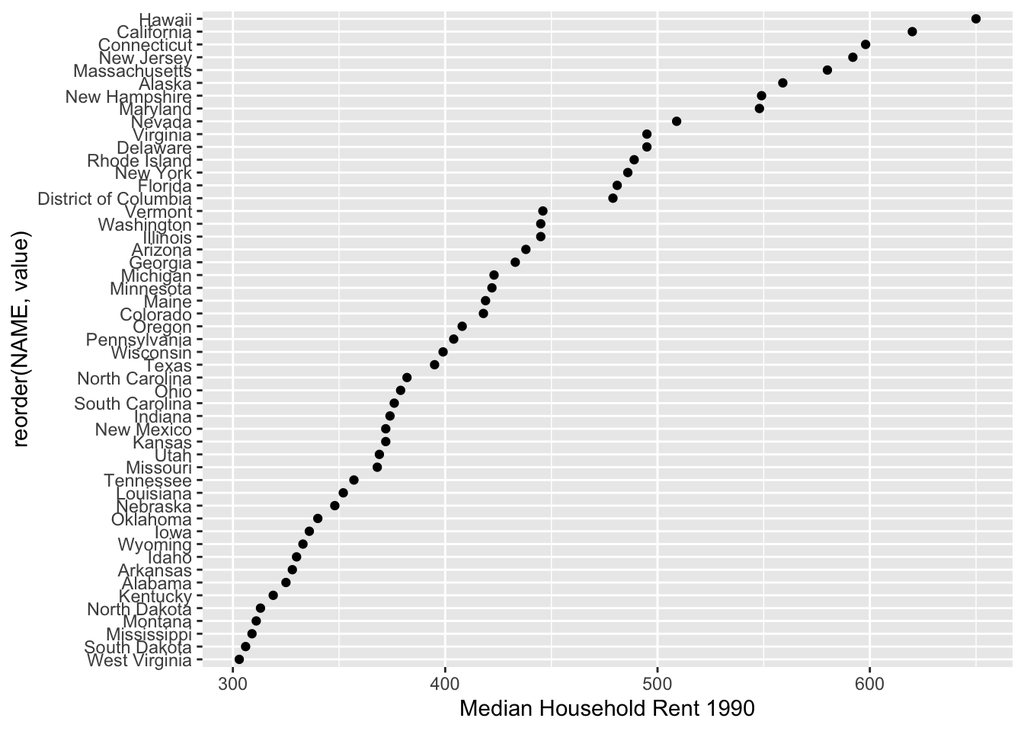

  ```r
  m90 %>%
    ggplot(aes(x = value, y = reorder(NAME, value))) +
    geom_point() + xlab("Median Household Rent 1990")
  ```

## 2.3 Searching for Variable Identifiers

- Getting variables from the Census or ACS requires knowing the variable ID - and there are thousands of these IDs across the different Census files.
- To rapidly search for variables, use the `load_variables()` function.
  - Two required arguments:
    - the year of the Census or end year of the ACS sample, and
    - the dataset - one of [“sf1”](https://factfinder.census.gov/help/en/summary_file_1_sf_1.htm), [“sf3”](https://www.census.gov/census2000/sumfile3.html), or “acs5”.
- For ideal functionality, you may want to assign the result of this function to a variable, setting `cache = TRUE` to store the result on your computer for future access.
- View and filter or use R to search the categories etc,,
- The names for the same type of data may be different across files and years

  ```r
  v17 <- load_variables(2017, "acs5", cache = TRUE)
  categories <- enframe(sort(unique(str_extract(v17$concept,"^.{35}"))))

  #View(v17)
  ```

### 2.3.1 Find the variable for median gross rent for the 2000 census in the sf3 file

- use `load_variables()`

  ```r
  c32000 <- load_variables(2000, "sf3", cache = TRUE)
  #view(c32000) # use filters to find median gross rent
  #median gross rent H063001

  c32000 %>%
    filter(str_detect(label, "^Median gross rent")) %>%
    select(name, label)
  ```

### 2.3.2 Get the 2000 Census data

- Use `get_decennial()`

  ```r
  m2000 <- get_decennial(geography = "state", variables = "H063001", year = 2000, key = Sys.getenv("CENSUS_API_KEY"))
  head(m2000)
  ```

  ```r
  nrow(m2000)
  ```

  ```
  ## [1] 52
  ```

# 3 Mapping with Census Data

## 3.1 Set up the environment with the required libraries for mapping

- The tidycensus package makes it easier to work with census data - **you need a census API key**
- The `SimpleFeatures` (`sf`) R package provides a standardized way to encode spatial vector data.
  - It binds to ‘GDAL’ for reading and writing data, to ‘GEOS’ for geometrical operations, and to ‘PROJ’ for projection conversions and datum transformations.
- To save the census tract data between sessions set the option: `options(tigris_use_cache = TRUE)`
- viridis color palettes are perceptually uniform and legible to colorblind individuals and in black and white.
  - viridis palettes are popular for data visualization, including for choropleth mapping.

    ```r
    # install.packages for the following
    library(tidyverse)
    library(tidycensus)
    library(tigris)
    library(sf)
    library(viridis) #a color palette
    options(tigris_use_cache = TRUE)
    ```

## 3.2 Download Census Data with geography (simpler features) objects

- [See here for the possible levels](https://www.census.gov/programs-surveys/economic-census/guidance-geographies/levels.html)
- The following example gets median household income from the 2014-2018 ACS for census tracts for Baltimore City

  ```r
  baltimore <- get_acs(state = "MD", county = "Baltimore City", geography = "tract",
                    variables = "B19013_001", geometry = TRUE, key = Sys.getenv("CENSUS_API_KEY"))
  #head(baltimore)
  ```

- We can quickly turn into a plot

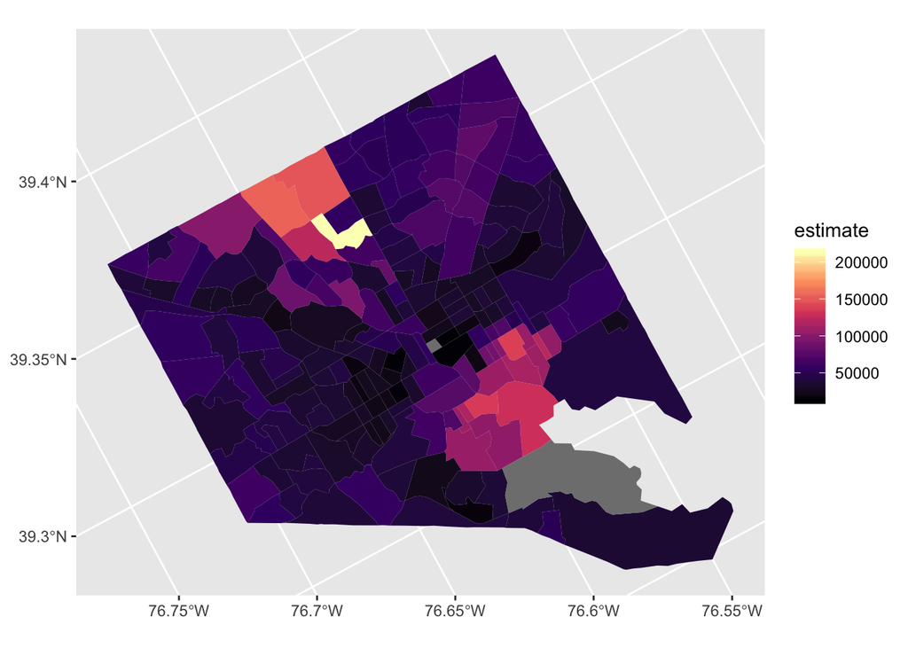

  ```r
  baltimore %>%
  ggplot(aes(fill = estimate)) +
    geom_sf(color = NA) +
    coord_sf(crs = 26911) +
    scale_fill_viridis_c(option = "magma")
  ```

## 3.3 Faceted Mapping

- ggplot2’s support for small multiples works very well with the tidy data format returned by tidycensus.
- Many Census and ACS variables return counts, which are generally inappropriate for choropleth mapping.
- However, `get_decennial()` and `get_acs()` have an optional argument, `summary_var,` that can work as a multi-group denominator.

### 3.3.1 Example of Racial Data

- Let’s get data for non-Hispanic whites, non-Hispanic blacks, non-Hispanic Asians, and Hispanics by Census tract for the 2010 Census, and specify total population as the summary variable. `year` is not necessary here as the default is 2010.

  ```r
  racevars <- c(White = "P005003",
                Black = "P005004",
                Asian = "P005006",
                Hispanic = "P004003")
  baltimore_race <- get_decennial(state = "MD", county = "Baltimore City",
                                  geography = "tract",
                                  variables = racevars, geometry = TRUE,
                                  summary_var = "P001001",
                                  key = Sys.getenv("CENSUS_API_KEY"))
  #head(baltimore_race)
  ```

- Plot percent by Tract

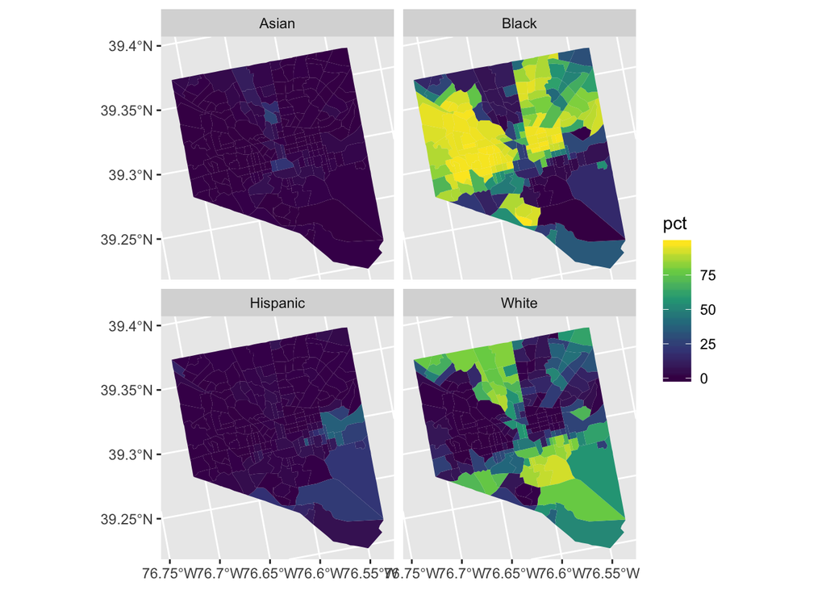

  ```r
  baltimore_race %>%
    mutate(pct = 100 * (value / summary_value)) %>%
    ggplot(aes(fill = pct)) +
    facet_wrap(~variable) +
    geom_sf(color = NA) +
    coord_sf(crs = 26915) +
    scale_fill_viridis_c()
  ```

# 4 Go interactive in HTML with the mapview package

- Allows you to interact with scroll, and zoom

  ```r
  library(mapview)
  mapview(baltimore, zcol = "estimate")
  ```

[interactive chart not shown]

## 4.1 DC Example with External (Non-Census) Data

- Download the median house hold income for DC at the census tract level with geography objects
- Add an explicit variable for CENSUS_TRACT from the GEOID

  ```r
  dc_median <- get_acs(state = "DC", county = "District of Columbia", geography = "tract",
                    variables = "B19013_001", geometry = TRUE, key = Sys.getenv("CENSUS_API_KEY"))
  dc_median %>%
    mutate(CENSUS_TRACT = str_sub(GEOID,6,11)) ->
    dc_median
  #head(dc_median)
  ```

### 4.1.1 Plot the median household income

- Variable is estimate

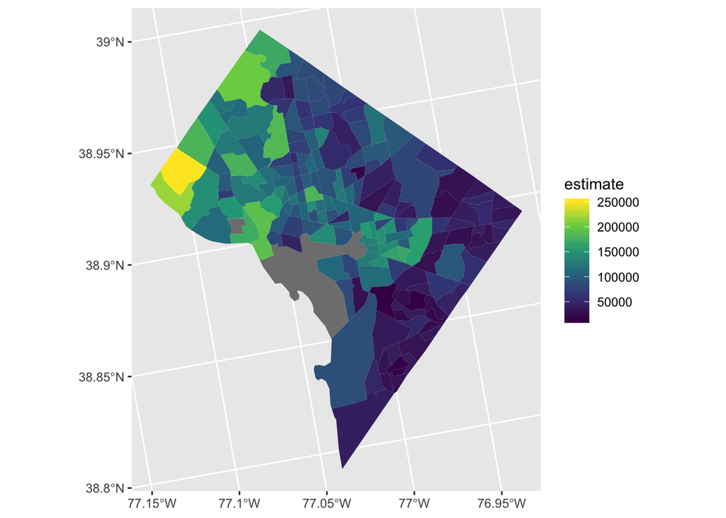

  ```r
  dc_median %>%
  ggplot(aes(fill = estimate)) +
      geom_sf(aes(geometry = geometry),color = NA) +
      coord_sf(crs = 26915) +
      scale_fill_viridis_c()
  ```

### 4.1.2 Get an External Crime data

- Use saved CSV form DC open Data

  ```r
  crime <- read_csv("./data/dc-crimes-search-results.csv", col_types = cols(DISTRICT = col_factor(),
                                                                           WARD = col_factor(),
                                                                           PSA = col_factor(),
                                                                           METHOD= col_factor()
                                                                           ))
  ```

### 4.1.2 Plot Crimes by Census Tract

- Note have to explicitly identify the geometry given the join

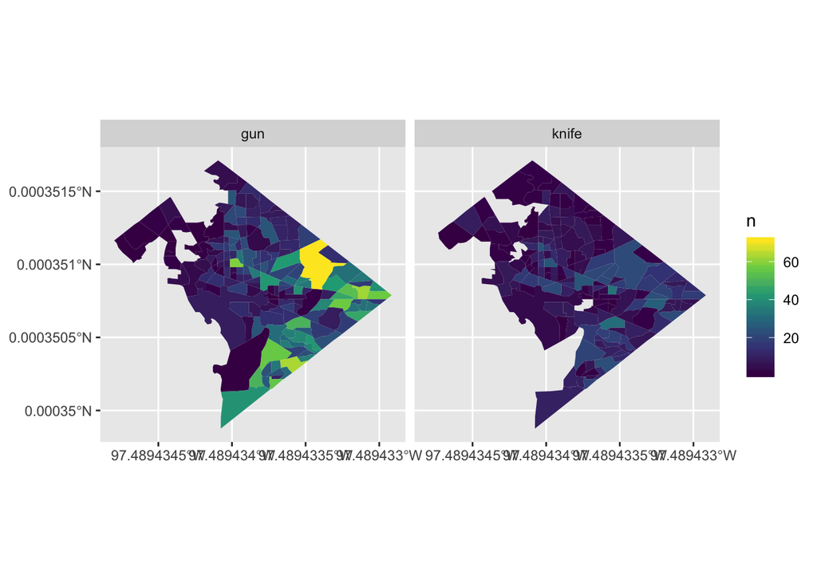

  ```r
  crime %>%
    filter(METHOD != "others") %>%
    group_by(CENSUS_TRACT, METHOD) %>%
    count() %>%
    left_join(dc_median) %>%
    ggplot(aes(fill = n)) +
      geom_sf(aes(geometry = geometry),color = NA) +
      coord_sf(crs = 26915) +
      scale_fill_viridis_c() +
      facet_wrap(~METHOD)
  ```

## 4.2 Now Get Shape Files for the Wards

- [Download from DC open data for the wards](https://opendata.dc.gov/datasets/ward-from-2012/data)
- Unzip in a directory
- Use the sf package function `read_sf()` to load using the directory name (not a file name)

  ```r
  wards <- read_sf("./data/Ward_from_2012")
  wards %>%
    mutate(WARD = parse_factor(as.character(WARD))) ->
    wards
     # head(wards)
  ```

- Now plot at the Ward Level

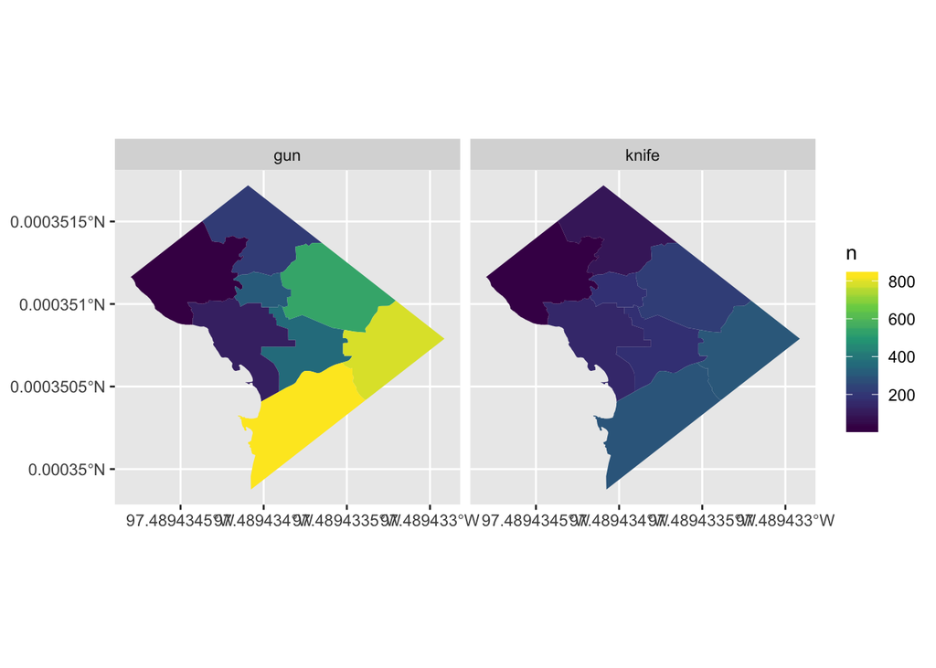

  ```r
  crime %>%
    filter(METHOD != "others") %>%
    group_by(WARD, METHOD) %>%
    count() %>%
    left_join(wards) %>%
    ggplot(aes(fill = n)) +
      geom_sf(aes(geometry = geometry),color = NA) +
      coord_sf(crs = 26915) +
      scale_fill_viridis_c() +
      facet_wrap(~METHOD)
  ```

- Compare totals by ward

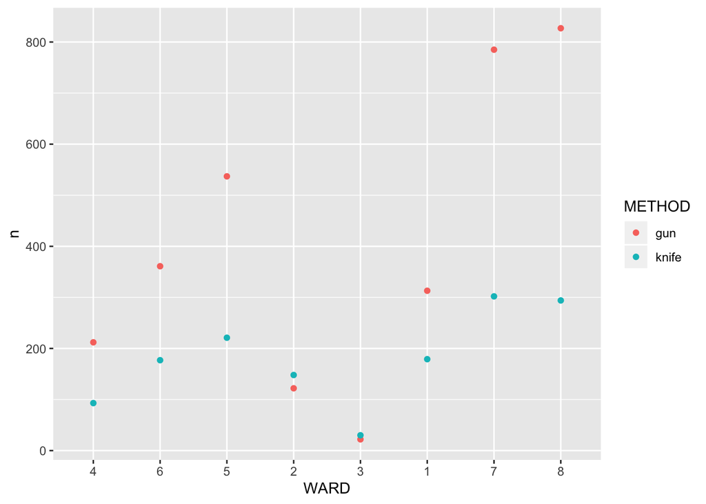

  ```r
  crime %>%
    filter(METHOD != "others") %>%
    group_by(WARD, METHOD) %>%
    count() %>%
    ggplot(aes(x = WARD, y = n, color = METHOD)) +
    geom_point()
  ```

  ```r
  crime %>%
    select(CENSUS_TRACT, WARD) %>%
    group_by(CENSUS_TRACT) %>%
    unique() %>%
    count() %>%
    filter(n>1) %>%
    arrange(desc(n))
  ```

## 4.3 Add Points of interest to the maps

- Get and set the lat long for AU as a sf object

  ```r
  au_latlong <- data.frame(longitude = -77.0888, latitude = 38.9375)
  au_latlong<- st_as_sf(au_latlong, coords = c("longitude", "latitude"),
      crs = 4326, agr = "constant")
  ```

- Add to the crime plot

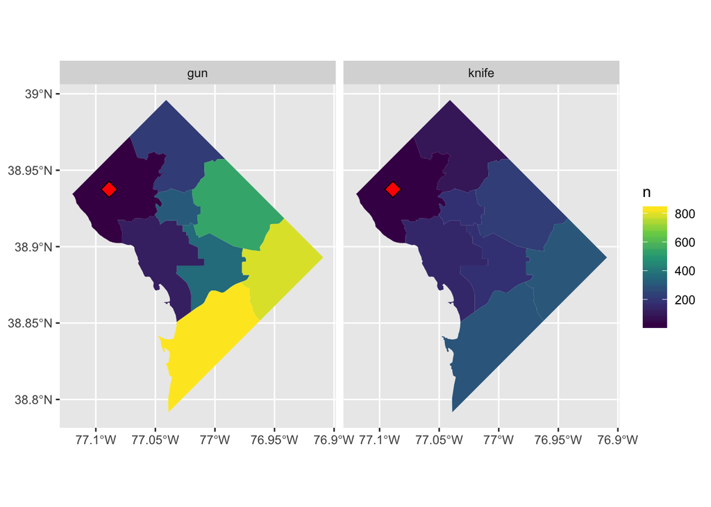

  ```r
  crime %>%
    filter(METHOD != "others") %>%
    group_by(WARD, METHOD) %>%
    count() %>%
    left_join(wards) %>%
    ggplot(aes(fill = n)) +
      geom_sf(aes(geometry = geometry),color = NA) +
      coord_sf(crs = 26915) +
      scale_fill_viridis_c() +
      facet_wrap(~METHOD) +
     geom_sf(data = au_latlong, size = 4, shape = 23, fill = "red")
  ```

- Add to the median household income plot

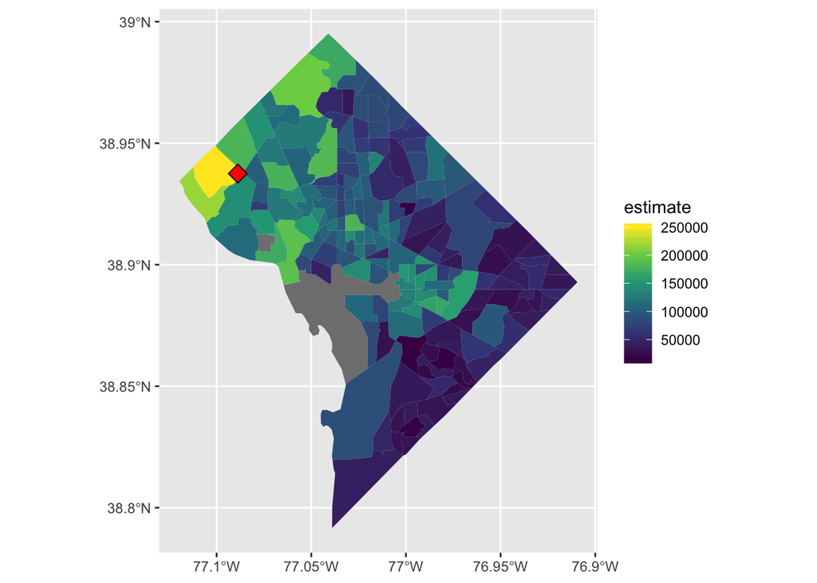

  ```r
  dc_median %>%
  ggplot(aes(fill = estimate)) +
      geom_sf(aes(geometry = geometry),color = NA) +
      coord_sf(crs = 26915) +
      scale_fill_viridis_c() +
     geom_sf(data = au_latlong, size = 4, shape = 23, fill = "red")
  ```